# **JAPAN HOUSEHOLD SPENDING 2000-2017 : A STRUCTURAL STORY**

### **Insight 6: Japan's Spending Hierarchy Is Being Quietly Rewritten — The 18-Year Rank Story**

**Business Importance:** Absolute spending tells you size. Rank tells you priority. A bump chart shows how each category's position in the household spending hierarchy has changed over 18 years — Medical Care climbing, Clothing falling. For brand positioning teams, ranking matters as much as volume: being the #2 priority category is fundamentally different from being #8.

**Design Choices — Course Principles Applied:**

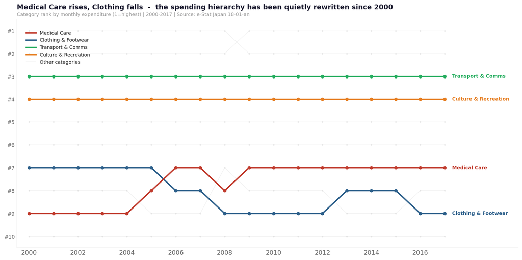

```python
ranked = df_top.rank(axis=1, ascending=False).astype(int)

highlight = {
    'Medical Care':         ACCENT,
    'Clothing & Footwear':  BLUE,
    'Transport & Comms':    GREEN,
    'Culture & Recreation': ORANGE,
}

fig, ax = plt.subplots(figsize=(13, 6.5))

for cat in TOP_CATS:
    r = ranked[cat].values
    c = highlight.get(cat, '#CCCCCC')
    lw    = 2.5 if cat in highlight else 0.8
    alpha = 1.0 if cat in highlight else 0.3
    ax.plot(df_top.index, r, color=c, linewidth=lw, alpha=alpha,
            marker='o', markersize=5 if cat in highlight else 2, zorder=3 if cat in highlight else 1)
    if cat in highlight:
        ax.text(2017.3, r[-1], cat, va='center', ha='left',
                fontsize=8.5, color=c, fontweight='bold')

ax.set_ylim(len(TOP_CATS)+0.5, 0.5)
ax.set_yticks(range(1, len(TOP_CATS)+1))
ax.set_yticklabels(["#{}".format(i) for i in range(1,len(TOP_CATS)+1)], fontsize=9)
ax.set_xticks(range(2000,2018,2))
ax.set_xlim(1999.5, 2020)
ax.spines['left'].set_color('#EEEEEE')
ax.spines['bottom'].set_color('#EEEEEE')
ax.tick_params(length=0)

leg_els = [Line2D([0],[0], color=c, lw=2.5, label=cat)
           for cat, c in highlight.items()]
leg_els.append(Line2D([0],[0], color='#CCCCCC', lw=0.8, alpha=0.5, label='Other categories'))
ax.legend(handles=leg_els, frameon=False, fontsize=8.5, loc='upper left', bbox_to_anchor=(0.01,0.97))

ax.set_title("Medical Care rises, Clothing falls  -  the spending hierarchy has been quietly rewritten since 2000",
             fontsize=12, fontweight='bold', color=DARK, pad=18, loc='left')
ax.text(0, 1.015, "Category rank by monthly expenditure (1=highest) | 2000-2017 | Source: e-Stat Japan 18-01-an",
        transform=ax.transAxes, fontsize=8.5, color='#999999')

plt.tight_layout()
plt.savefig('insight6_bump_rank.png', dpi=150, bbox_inches='tight')
plt.show()
```

### **Insight 7: Ten Categories, Ten Different Stories — The Full Picture Without the Spaghetti**

**Business Importance:** Overlaying 10 trend lines on one chart creates visual chaos. Small multiples apply the same chart format to each category, enabling category-level teams to see their own story without noise. Each panel is a standalone executive briefing for one business unit.

**Design Choices — Course Principles Applied:**

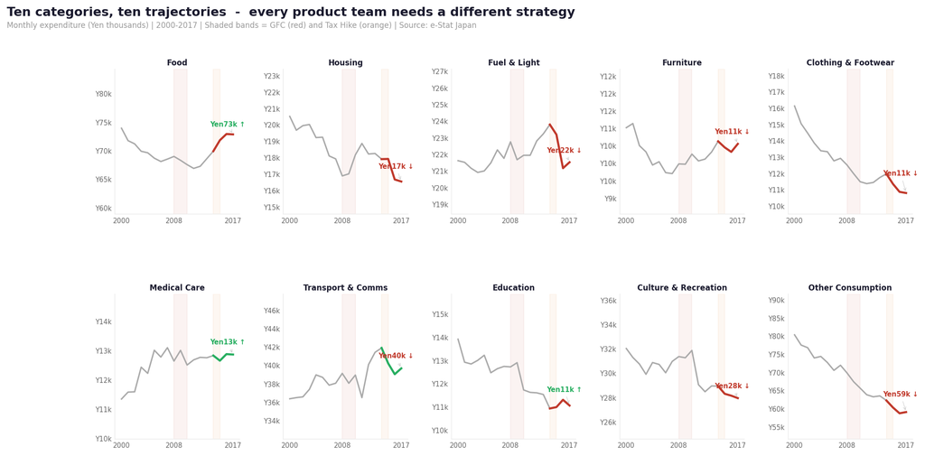

```python
fig = plt.figure(figsize=(15, 7))
gs  = GridSpec(2, 5, figure=fig, hspace=0.55, wspace=0.35)

yrs_list = df_top.index.tolist()

for idx, cat in enumerate(TOP_CATS):
    r, c2 = divmod(idx, 5)
    ax = fig.add_subplot(gs[r, c2])
    vals = df_top[cat].values / 1000

    ax.axvspan(2008, 2010, alpha=0.06, color=ACCENT, zorder=0)
    ax.axvspan(2014, 2015, alpha=0.06, color=ORANGE, zorder=0)

    ax.plot(yrs_list, vals, color='#AAAAAA', linewidth=1.5, zorder=2)
    ax.plot(yrs_list[-4:], vals[-4:],
            color=ACCENT if vals[-1] < vals[0] else GREEN,
            linewidth=2.2, zorder=3)

    ax.set_xlim(1999, 2018)
    ax.set_ylim(vals.min()*0.88, vals.max()*1.14)
    ax.set_xticks([2000, 2008, 2017])
    ax.tick_params(labelsize=7, length=0)
    ax.yaxis.set_major_formatter(mticker.FuncFormatter(lambda x,_: "Y{:.0f}k".format(x)))
    ax.spines['left'].set_color('#EEEEEE')
    ax.spines['bottom'].set_color('#EEEEEE')

    trend = 'up' if vals[-1] > vals[-4] else 'down'
    arr   = '↑' if trend == 'up' else '↓'
    tc    = GREEN if trend == 'up' else ACCENT
    end_lbl = "Yen{:.0f}k {}".format(vals[-1], arr)
    ax.annotate(end_lbl, xy=(2017, vals[-1]),
                xytext=(2013.5, vals[-1]+(vals.max()-vals.min())*0.2),
                fontsize=7, color=tc, fontweight='bold',
                arrowprops=dict(arrowstyle='->', color='#CCCCCC', lw=0.5))
    ax.set_title(cat, fontsize=8, fontweight='bold', color=DARK, pad=4)

fig.suptitle("Ten categories, ten trajectories  -  every product team needs a different strategy",
             fontsize=13, fontweight='bold', color=DARK, y=1.01, x=0.02, ha='left')
fig.text(0.02, 0.98, "Monthly expenditure (Yen thousands) | 2000-2017 | Shaded bands = GFC (red) and Tax Hike (orange) | Source: e-Stat Japan",
         fontsize=8, color='#999999', va='top')

plt.savefig('insight7_small_multiples_ts.png', dpi=150, bbox_inches='tight')
plt.show()
```